# rXTalkViz

# Introduction

The rXTalkViz package provides tools for quantifying and visualizing cross-talks between biological pathways by employing. It models the pathway cross-talks in two categories, 1) via share nodes (genes/proteins/molecules) - defined as Type-I cross, and 2) via shared interactions (Protein-Protein interaction, or data-driven interactoins) - defined as Type-II cross-talks. Here, the Type-I and Type-II cross-talks are quantified with Jaccard-Index score, and Network proximity scores, respectively. Visualization includes Network plots, Shankey diagram, and Heatmap plots. Finally, the whole quantification result is also saved as spreadsheet (as a csv file). This vignette will guide you through the basic usage of the package, including how to load the data, perform cross-talk analysis, and visualize the results.

## Step 1: Loading the Required Libraries

First, we need to load the necessary libraries, including rXTalkViz and other dependencies such as dplyr and data.table.

```r
library(rXTalkViz)
library(dplyr)
library(data.table)
```

## Step 2: Loading Example Data

The package comes with an example dataset named example_enrich.df. Let’s observe the head of this data to understand its structure.

```r
print(head(example_enrich.df))
```

```
#>                                             Description
#> 1  AGE-RAGE signaling pathway in diabetic complications
#> 2                                AMPK signaling pathway
#> 3                                Acute myeloid leukemia
#> 4                                     Adherens junction
#> 9                                     Alzheimer disease
#> 11                                Amphetamine addiction
#>                                                                                                                                                                                                                                                                                                          …
#> 1                                                                                                                                                                                                                                                                                                        …
#> 2                                                                                                                                                                                                                                                                                                        …
#> 3                                                                                                                                                                                                                                                                                                        …
#> 4                                                                                                                                                                                                                                                                                                        …
#> 9  BAD/TPTEP2-CSNK1E/GRIN2D/DKK1/DKK2/GRIN2C/ATG14/ATG13/DKK4/PSMC6/MAPK10…-KCTD14/COX6A1/KIF5A/NRAS/TUBB8/TUBA3E/TUBB6/TUBA3D/KIF5C/TUB…
#> 11                                                                                                                                                                                                                                                                                                       …
#>                                                                                                                                                    Overlapping.geneSymbol
#> 1                                                                                                         VCAM1/BAX/CCND1/AKT1/SMAD4/PIK3R1/JUN/FN1/BCL2/CASP3/MAPK1/JAK2
#> 2                                                                                                              CCND1/AKT1/PIK3R1/PPP2R5C/PPP2R5B/ELAVL1/PCK2/PPP2CA/RAB10
#> 3                                                                                                                                       CCND1/AKT1/PIK3R1/GRB2/MAPK1/CD14
#> 4                                                                                                                                   PTPRJ/EGFR/ACTB/SMAD4/ACTG1/WAS/MAPK1
#> 9  APC/APP/CALML6/PSMD4/AKT1/BACE1/PIK3R1/PPP3R1/PPP3R2/APOE/TUBB/PPP3CA/PPP3CB/PPP3CC/TUBA1B/SDHA/PPIF/PPID/TRAF2/SLC25A4/ITPR1/UQCRFS1/CASP3/VDAC3/VDAC1/HSD17B10/MAPK1
#> 11                                                                                                              JUN/ATF2/CALML6/PPP3CA/PPP3CB/PPP3CC/CAMK2A/PPP3R1/PPP3R2
#>    Overlapping.geneID Count GeneRatio       pvalue    p.adjust
#> 1                  NA    12    12/355 0.0003494933 0.002337989
#> 2                  NA     9     9/355 0.0347056008 0.062341542
#> 3                  NA     6     6/355 0.0250513661 0.047646716
#> 4                  NA     7     7/355 0.0111798720 0.026131267
#> 9                  NA    27    27/355 0.0025884672 0.008447105
#> 11                 NA     9     9/355 0.0007035455 0.003499688
```

This dataset contains enrichment results for various pathways. We will use this data to explore the cross-talk analysis features of the package.

## Step 3: Filtering Data

To focus on the most significant pathways, we will filter the dataset to include only those pathways with an adjusted p-value (p.adjust) below 0.001. Moreover, this will greatly control the time required for running the whole pipeline by invoking the wrapper function.

```r
filtered_data <- example_enrich.df %>%
  filter(p.adjust < 0.001)
filtered_data %>% nrow
```

```
#> [1] 19
```

## Step 4: Performing Cross-Talk Analysis

With the filtered data, we can now perform cross-talk analysis using the xTalk_wrapper function. This function allows you to quantify, visualize cross-talks between pathways, and save all the results within the specified directory. Note, if the directory doesn’t exist, it will create on but with a warning, and the directory name can be specified by changing the ‘outdir’ parameter.

```r
# filtered_df <- example_enrich.df %>%
#   filter(p.adjust < 0.001)
# xTalk_wrapper(filtered_df,
#               doPlot = T,
#               doXtalkQuant = T,
#               nPermute = 2,
#               min_cross_talk_score = 1.0,
#               plot_width = 10,
#               plot_height = 10)
```

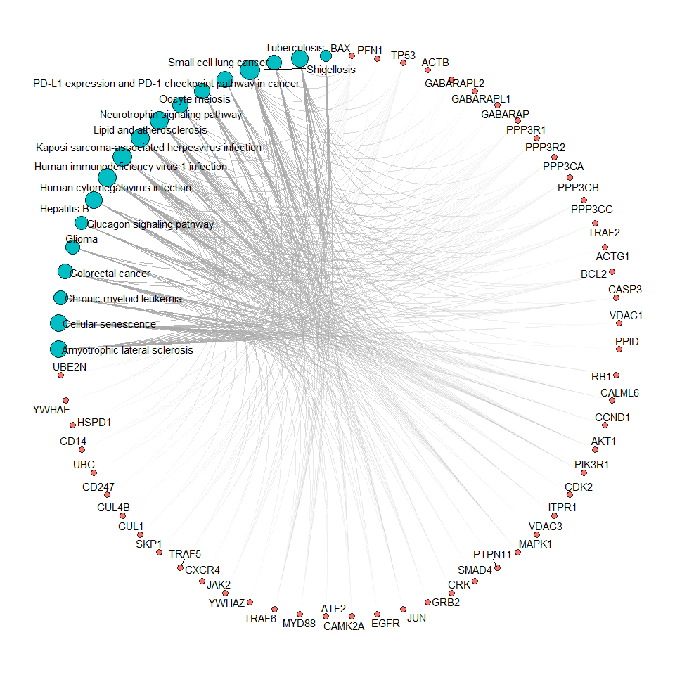

```r
filtered_df <- example_enrich.df %>%
  filter(p.adjust < 0.001)

p <- xTalkPlot.Type_I.NetworkView(
  enrich.df = filtered_df,
  string_PPI_score_th = string_PPI_score_th,
  showCategory = 100,
  layout = "linear",
  colorEdge = TRUE,
  circular = TRUE)
p
```

In this network plot, Type-I cross-talks is shown among highly enriched pathways via shared genes.

# Conclusion

In this vignette, we demonstrated the basic functionality of the rXTalkViz package. We loaded example data, filtered it based on significance, and performed cross-talk analysis. For more detailed analysis, refer to the package documentation.